# Inference Of Population Means

Mallikarjuna

2023-09-26

```r
# Load necessary packages
library(tidyverse)
library(ggthemes)
library(flextable)
```

```r
# Set ggplot theme for visualizations
theme_set(ggthemes::theme_few())

# Set options for flextables
set_flextable_defaults(na_str = "NA")

# Load function for printing tables nicely
source("https://raw.githubusercontent.com/dilernia/STA323/main/Functions/make_flex.R")
```

```r
# Get a sample

sample(1:100, size=10)
```

```
##  [1] 73 69 97 87 26 57 33 42 82 55
```

### Let’s import data from the website GitHub to use for this activity.

```r
# Load Palmer penguins data
penguins <- readr::read_csv("https://raw.githubusercontent.com/dilernia/STA323/main/Data/penguins.csv", show_col_types = FALSE)
```

### *As a researcher interested in penguins, we may be interested in the average flipper length (mm) of penguins from Palmer Archipelago, Antarctica. From our previous experience, we believe that penguins typically have an average flipper length of 200mm, but is this true for these penguins from Antarctica as well? We can explore this using a one-sample t-test.*

**Formally state the hypotheses for our question of interest.**

We are interested in testing whether the average flipper length of all penguins in Palmer Archipelago, Antarctica is equal to 200mm or not.

Formally, the hypotheses for our corresponding one-sample $t$-test are below.

H0: $\mu = 200$ vs. Ha:$\mu \ne 200$

where $\mu$ is average flipper length of all penguins in Palmer Archipelago, Antarctica.

**What is the null value, 0, for this test?**

$\mu_0 = 200$

```r
# Calculating descriptive statistics
quant1Stats <- penguins %>%
  dplyr::summarize(
  Minimum = min(flipper_length_mm, na.rm = TRUE),
  Q1 = quantile(flipper_length_mm, na.rm = TRUE, probs = 0.25),
  M = median(flipper_length_mm, na.rm = TRUE),
  Q3 = quantile(flipper_length_mm, na.rm = TRUE, probs = 0.75),
  Maximum = max(flipper_length_mm, na.rm = TRUE),
  Mean = mean(flipper_length_mm, na.rm = TRUE),
  R = Maximum - Minimum,
  s = sd(flipper_length_mm, na.rm = TRUE),
  n = n()
)

# Printing table of statistics
quant1Stats %>%
  make_flex(caption = "Quantitative summary statistics for penguin flipper lengths (mm).")
```

Table 1: Quantitative summary statistics for penguin flipper lengths (mm).

| Minimum | Q1 | M | Q3 | Maximum | Mean | R | s | n |
| --- | --- | --- | --- | --- | --- | --- | --- | --- |
| 172.00 | 190.00 | 197.00 | 213.00 | 231.00 | 200.92 | 59.00 | 14.06 | 344 |

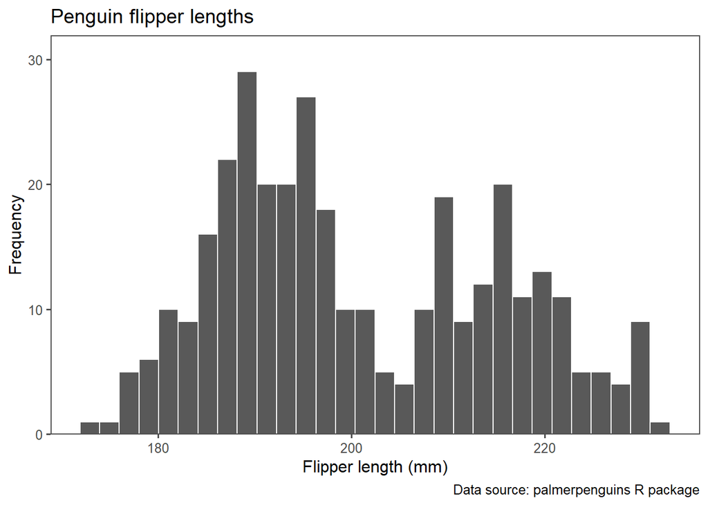

```r
# Creating a histogram
penguins %>%
  ggplot(aes(x = flipper_length_mm)) +
  geom_histogram(color = "white") +
  scale_y_continuous(expand = expansion(mult = c(0, 0.10))) +
  labs(title = "Penguin flipper lengths",
       x = "Flipper length (mm)",
       y = "Frequency",
       caption = "Data source: palmerpenguins R package")
```

```r
## `stat_bin()` using `bins = 30`. Pick better value with `binwidth`.
```

## Quantile-Quantile plot

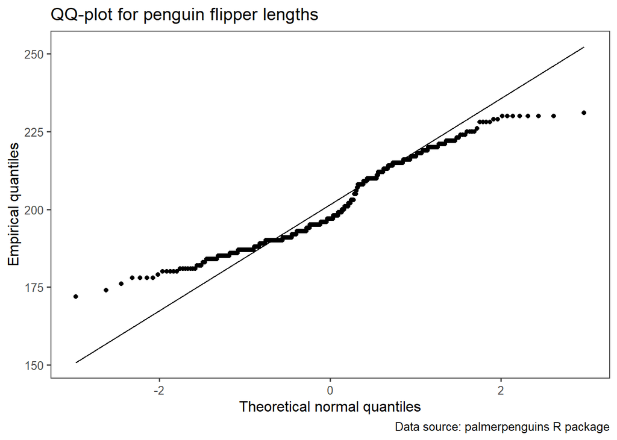

```r
# Creating a Quantile-Quantile (QQ) plot
penguins %>%
  ggplot(aes(sample = flipper_length_mm)) +
  stat_qq_line() +
  stat_qq() +
  labs(title = "QQ-plot for penguin flipper lengths",
       x = "Theoretical normal quantiles",
       y = "Empirical quantiles",
       caption = "Data source: palmerpenguins R package")
```

**State each assumption for the one-sample t-test, and indicate whether or not each assumption is met, citing specific evidence from the output obtained.**

1. **Independent Observations**: These measurements are for separate penguins and we assume they were randomly selected for the sake of the problem.
2. **Normality Assumption**: Since n = 344, which is larger than 100, the normality assumption is met as per Central Limit theorem.

## Next, we implement the one-sample t-test.

```r
# Implementing a one-sample t-test using R
ttestRes <- t.test(penguins$flipper_length_mm,
                   mu = 200, conf.level = 0.95)

# Printing model output
ttestRes %>%
  broom::tidy() %>%
  make_flex()
```

| estimate | statistic | p.value | parameter | conf.low | conf.high | method | alternative |
| --- | --- | --- | --- | --- | --- | --- | --- |
| 200.92 | 1.20 | 0.23 | 341.00 | 199.42 | 202.41 | One Sample t-test | two.sided |

**State our p-value, decision, and conclusion in the context of the problem testing at the 5% significance level, citing specific evidence from the obtained output.**

*p-value*: 0.23

*decision*: Since the p-value of 0.23 is grater than 0.05, we fail to reject H0.

*conclusion*: We have insufficient evidence that the mean flipper lengths of penguins in Palmer Archipelago, Antarctica differs from 200mm.

**Provide and interpret a 95% confidence interval for the average flipper length of penguins from Palmer Archipelago, Antarctica.**

CI limits for $\mu$: (199.42,202.41)

We are 95% confident that the mean flipper length of penguins in Palmer Archipelago, Antarctica is between 199.42mm and 202.41mm.

**Do the results of the t-test and 95% confidence interval align? Why or why not?**